# Stan Tutorial

June 25, 2017

## Module objective

In this module, we will fit a hierarchical multinomial logit model using choice based conjoint data for chocolate bars.

This will allow us to:  
- Learn more Stan syntax  
- Work with a hierarchical model  
- Fit a model that is commonly fit in marketing and usually requres specialized software

Many will be familar with estimating this model using Sawtooth CBC/HB or the ChoiceModelR package in R.

## More Stan syntax

## Hierarchical models

There is substantial evidence that different people have different preferences over the features of products. To accomodate this, we alter the multnomial logit model by allowing each person to have her own vector of part-worths for the attributes.

```stan
Y[r,s] ~ categorical_logit(X[r,s]*Beta[,r]);
```

Becuase there is typically insufficient data to estimate each person's `beta[,r]` vector, we then impose a distribution on the individual-level betas.

```stan
Beta[,r] ~ multi_normal(Theta*Z[,r], Sigma);
```

## Multivariate normal distribution

This is the first time we have seen a *multivariate* distribution in Stan. This is the *multivariate normal distribution.*

```stan
y ~ multi_normal(mu, Sigma);
```

`y` is a vector (or an array of vectors for multiple observations)  
`mu` is the mean vector  
`Sigma` is the covariance matrix.

If this distribution is new to you, check out the [wikipedia page](https://en.wikipedia.org/wiki/Multivariate_normal_distribution).

## Covariance matricies

Covariance matrices like `Sigma` are square matrices with special properties. Stan provides special data types just for storing covariance matrices:

```stan
corr_matrix[K] mycorrmatrix;
```

And there is a covariance matrix type as well:

```stan
cov_matrix[K] mycovmatrix;
```

## Other parameterizations

If you prefer other parameterizations of the multivariate normal, they are available.

```stan
y ~ multi_normal_prec(mu, Omega);
y ~ multi_normal_cholesky(mu, L);
```

There are even special types for Cholesy factors, if you are into that. (It can be important for computational efficiency.)

```stan
cholesky_factor_cov[K] L;
cholesky_factor_cor[K] L;
```

## Other multivariate distributions

Gaussian process

```stan
y ~ multi_gp(Sigma, w);
```

Multivariate Student t

```stan
y ~ multi_student_t(nu, mu, Sigma);
```

Gaussian DLM

```stan
y ~ gaussian_dlm_obs(F, G, V, W, m0, C0);
```

See the the [Stan Modeling Language Users Guide and Reference Manual](http://mc-stan.org/users/documentation/) for more!

## Priors for covariances

One of the difficult things about using the multivariate normal distribution is putting a prior on the covariance `Sigma.` Gibbs samplers often use the *inverted Wishart* prior, which is conjugate. And Stan supports that:

```stan
W ~ inv_wishart(nu, Sigma);
```

However, this prior often puts undue weight near `Sigma` and can influence the posterior in strange ways.

## LKJ Prior for correlations

Many analysts have an intuitive sense for correlations; they are always between -1 and 1 with zero indicating no association. The LKJ distribution puts a prior on the correlation matrix.

```stan
Omega ~ lkj_corr(eta);
```

If `eta = 1` then the density is uniform over all correlation matrices of a given order  
If `eta > 1` the identity matrix is the modal correlation matrix, with sharper peaks in the density around the identity matrix for larger `eta`. This allows us to reduce correlations, if we have prior beliefs that there are not many correlations between part-worths.

## Visualizing the LKJ prior

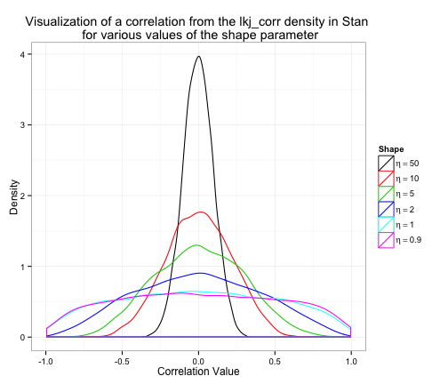

This image was borrowed from the [Psychstatistics blog](http://www.psychstatistics.com/2014/12/27/d-lkj-priors/), which illustrates how to use Stan to simulate from the LKJ prior to produce this visualization.

## Using LKJ to put a prior on covariance

```stan
parameters{
  corr_matrix[K] Omega;
  vector<lower=0>[K] tau;
}
model{
  Omega ~ lkj_corr(2);
  Beta[,r] ~ multi_normal(mu, quad_form_diag(Omega, tau));
}
```

## Truncated distributions

You can truncate any distribution using this syntax:

```stan
mu ~ normal(mu, sigma) T[lower, upper];
```

## Assignment

Occasionally, you may need to assign one variable (data or parameter) to another, e.g. when you are tranforming data internally in Stan. To do that we use `=`.

The symbol `~` is for sampling statements that define random variables.

We will use truncation and assignment in just a few more slides.

## Hierarchical multnomial logit model in Stan

Enough syntax! Let's get on to the model. You can open the full model specification in `hmnl.stan`.

## Data

Putting all of that new syntax together, we can specify a hierarchical multinomial logit model.

```stan
data {
  int<lower=2> C; // # of alternatives (choices) in each scenario
  int<lower=1> K; // # of covariates of alternatives
  int<lower=1> R; // # of respondents
  int<lower=1> S; // # of scenarios per respondent
  int<lower=0> G; // # of respondent covariates
  int<lower=1,upper=C> Y[R, S]; // observed choices
  matrix[C, K] X[R, S]; // matrix of attributes for each obs
  matrix[G, R] Z; // vector of covariates for each respondent
}
```

## Parameters

```stan
parameters {
  matrix[K, R] Beta;
  matrix[K, G] Theta;
  corr_matrix[K] Omega;
  vector<lower=0>[K] tau;
}
```

## Transformed parameters

```stan
transformed parameters {
  cov_matrix[K] Sigma = quad_form_diag(Omega, tau);
}
```

## Model

We can use any transformed parameters in our model block.

```stan
model {
  //priors
  to_vector(Theta) ~ normal(0, 10);
  tau ~ cauchy(0, 2.5);
  Omega ~ lkj_corr(2);
  //likelihood
  for (r in 1:R) {
    Beta[,r] ~ multi_normal(Theta*Z[,r], Sigma);
    for (s in 1:S)
      Y[r,s] ~ categorical_logit(X[r,s]*Beta[,r]);
  }
}
```

## Bayesian inference

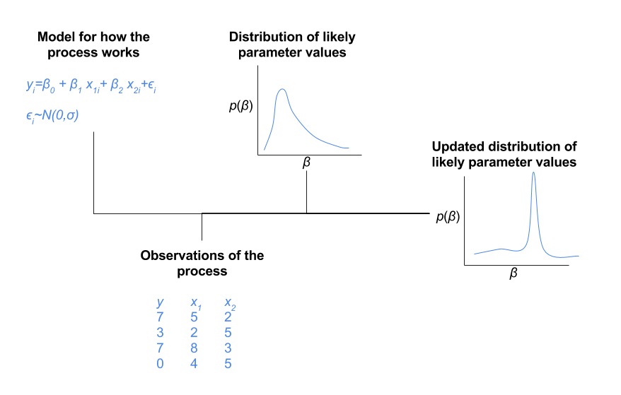

## Get setup in R

It's time to open the `hmnl.R` file and start running R code.

```r
library(rstan)
library(MASS)
library(shinystan)
# writes a compiled Stan program to the disk to avoid recompiling
rstan_options(auto_write=TRUE)
# allows Stan chains to run in parallel on multiprocessor machines
options(mc.cores = parallel::detectCores())
```

## Testing the hierarchical multinomial logit model with synthetic data

It's a good idea to test any new model with synthetic data.

## Synthetic data generation function (1)

```r
# function to generate mnl data
generate_hmnl_data <- function(R=100, S=30, C=3,
                               Theta=matrix(rep(1, 8), nrow=2),
                               Sigma=diag(0.1, 4)){
  K <- ncol(Theta)
  G <- nrow(Theta)
  Y <- array(dim=c(R, S))
  X <- array(rnorm(R*S*C*K), dim=c(R, S, C, K)) # normal covariates
  Z <- array(dim=c(G, R))
  Z[1,] <- 1  # intercept
  if (G > 1) {
    Z[2:G,] <- rnorm(R*(G-1)) # normal covariates
  }
  Beta <- array(dim=c(K, R))
  for (r in 1:R) {
    Beta[,r] <- mvrnorm(n=1, mu=Z[,r]%*%Theta, Sigma=Sigma)
    for (s in 1:S)
      Y[r,s] <- sample(x=C, size=1, prob=exp(X[r,s,,]%*%Beta[,r]))
   }
  list(R=R, S=S, C=C, K=K, G=G, Y=Y, X=X, Z=Z,
       beta.true=beta, Theta.true=Theta, Sigma.true=Sigma)
}
```

## Synthetic data generation function (2)

```r
 for (r in 1:R) {
    Beta[,r] <- mvrnorm(n=1, mu=Z[,r]%*%Theta, Sigma=Sigma)
    for (s in 1:S)
      Y[r,s] <- sample(x=C, size=1, prob=exp(X[r,s,,]%*%Beta[,r]))
   }
  list(R=R, S=S, C=C, K=K, G=G, Y=Y, X=X, Z=Z,
       beta.true=beta, Theta.true=Theta, Sigma.true=Sigma)
}
```

## Synthetic data

```r
d1 <- generate_hmnl_data()
str(d1)
```

```
## List of 11
##  $ R         : num 100
##  $ S         : num 30
##  $ C         : num 3
##  $ K         : int 4
##  $ G         : int 2
##  $ Y         : int [1:100, 1:30] 1 1 1 3 3 2 2 2 2 3 ...
##  $ X         : num [1:100, 1:30, 1:3, 1:4] 1.032 1.176 -0.245 1.586 1.252 ...
##  $ Z         : num [1:2, 1:100] 1 -1.7 1 -0.95 1 ...
##  $ beta.true :function (a, b)
##  $ Theta.true: num [1:2, 1:4] 1 1 1 1 1 1 1 1
##  $ Sigma.true: num [1:4, 1:4] 0.1 0 0 0 0 0.1 0 0 0 0 ...
```

## Running the hmnl on synthetic data

```r
test.stan <- stan(file="hmnl.stan", data=d1, iter=1000, chains=4)
```

## Traceplots: Theta

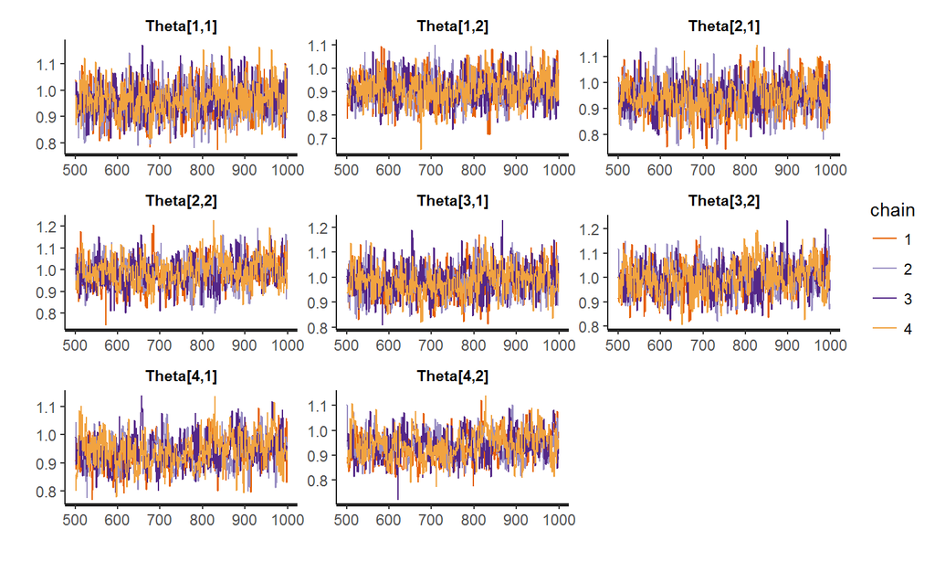

```r
plot(test.stan, plotfun="trace", pars=("Theta"))
```

## Traceplots: tau

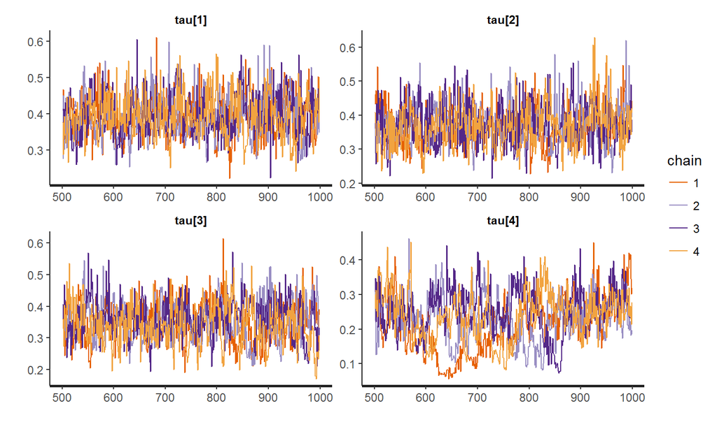

```r
plot(test.stan, plotfun="trace", pars=c("tau"))
```

## Traceplots: Omega

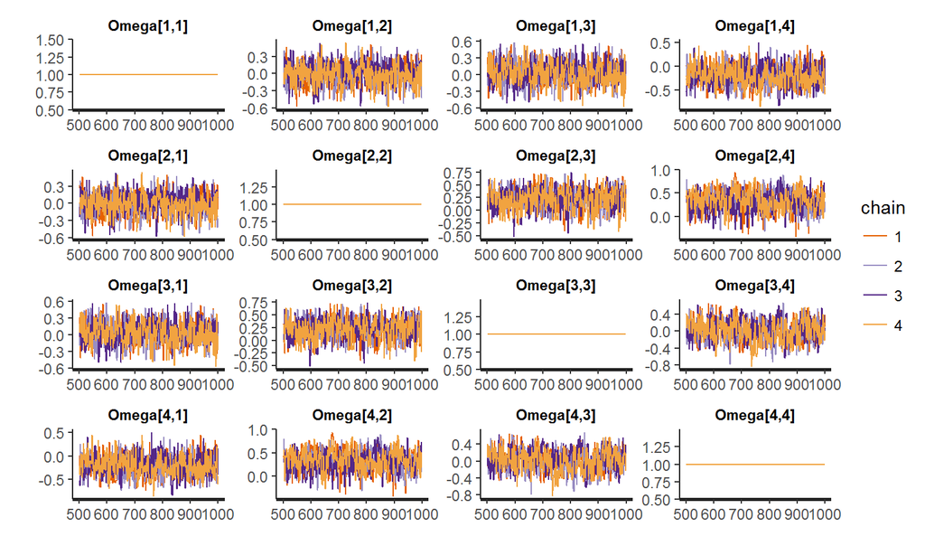

```r
plot(test.stan, plotfun="trace", pars=("Omega"))
```

## Summary: Theta (Population means of part-worths)

```r
summary(test.stan, pars=c("Theta"))$summary
```

```
##                 mean     se_mean         sd      2.5%       25%       50%
## Theta[1,1] 0.9587377 0.002334090 0.06280649 0.8375439 0.9156850 0.9561942
## Theta[1,2] 0.9098105 0.002268736 0.06138482 0.7917715 0.8690832 0.9078003
## Theta[2,1] 0.9421295 0.002703030 0.06138325 0.8204883 0.9008087 0.9410527
## Theta[2,2] 0.9880184 0.002944168 0.06403487 0.8647451 0.9442143 0.9873797
## Theta[3,1] 0.9827931 0.002530934 0.05895814 0.8713475 0.9427501 0.9820535
## Theta[3,2] 0.9966323 0.002731505 0.06253682 0.8746371 0.9547595 0.9955977
## Theta[4,1] 0.9395517 0.003826270 0.05449499 0.8396224 0.9024615 0.9368264
## Theta[4,2] 0.9366372 0.002962184 0.05625473 0.8338732 0.8960819 0.9348647
##                  75%    97.5%    n_eff     Rhat
## Theta[1,1] 0.9987374 1.088837 724.0587 1.007812
## Theta[1,2] 0.9491400 1.038180 732.0724 1.006959
## Theta[2,1] 0.9820919 1.066249 515.7009 1.010937
## Theta[2,2] 1.0296458 1.114342 473.0508 1.012248
## Theta[3,1] 1.0199481 1.102844 542.6579 1.016916
## Theta[3,2] 1.0369580 1.123622 524.1645 1.012375
## Theta[4,1] 0.9731733 1.053707 202.8438 1.024926
## Theta[4,2] 0.9745459 1.049382 360.6566 1.024565
```

```r
summary(test.stan, pars=c("tau"))$summary
```

```
##             mean     se_mean         sd       2.5%       25%       50%
## tau[1] 0.3949651 0.002538435 0.05746666 0.29130675 0.3561366 0.3927558
## tau[2] 0.3701343 0.002584499 0.05829174 0.26936828 0.3300726 0.3659506
## tau[3] 0.3522182 0.003242636 0.06135016 0.23388741 0.3102004 0.3518041
## tau[4] 0.2321432 0.009612778 0.06992072 0.08901003 0.1868318 0.2341356
##              75%     97.5%     n_eff     Rhat
## tau[1] 0.4325391 0.5146348 512.50712 1.000990
## tau[2] 0.4063796 0.4934210 508.69966 1.006871
## tau[3] 0.3939921 0.4689495 357.96035 1.008733
## tau[4] 0.2770319 0.3671950  52.90709 1.086912
```

## Summary: Omega (Populaltion correlations of part-worths)

```r
summary(test.stan, pars=c("Omega"))$summary
```

```
##                   mean      se_mean           sd       2.5%        25%
## Omega[1,1]  1.00000000 0.000000e+00 0.000000e+00  1.0000000  1.0000000
## Omega[1,2] -0.01315695 7.659746e-03 1.892900e-01 -0.3961260 -0.1433309
## Omega[1,3]  0.03882352 7.939863e-03 1.930818e-01 -0.3464463 -0.0970887
## Omega[1,4] -0.20380616 1.121891e-02 2.136722e-01 -0.6108545 -0.3492228
## Omega[2,1] -0.01315695 7.659746e-03 1.892900e-01 -0.3961260 -0.1433309
## Omega[2,2]  1.00000000 2.139921e-18 9.432721e-17  1.0000000  1.0000000
## Omega[2,3]  0.23007192 7.885467e-03 1.971598e-01 -0.1841694  0.1025905
## Omega[2,4]  0.33505140 1.265876e-02 2.216721e-01 -0.1006862  0.1841152
## Omega[3,1]  0.03882352 7.939863e-03 1.930818e-01 -0.3464463 -0.0970887
## Omega[3,2]  0.23007192 7.885467e-03 1.971598e-01 -0.1841694  0.1025905
## Omega[3,3]  1.00000000 2.429172e-18 1.055560e-16  1.0000000  1.0000000
## Omega[3,4]  0.02454755 1.338966e-02 2.428951e-01 -0.4670754 -0.1449424
## Omega[4,1] -0.20380616 1.121891e-02 2.136722e-01 -0.6108545 -0.3492228
## Omega[4,2]  0.33505140 1.265876e-02 2.216721e-01 -0.1006862  0.1841152
## Omega[4,3]  0.02454755 1.338966e-02 2.428951e-01 -0.4670754 -0.1449424
## Omega[4,4]  1.00000000 2.471956e-18 1.105492e-16  1.0000000  1.0000000
##                     50%         75%     97.5%     n_eff     Rhat
## Omega[1,1]  1.000000000  1.00000000 1.0000000 2000.0000      NaN
## Omega[1,2] -0.007716174  0.11972664 0.3385241  610.6983 1.009589
## Omega[1,3]  0.037330150  0.17470254 0.4053796  591.3662 1.011584
## Omega[1,4] -0.214921922 -0.06483368 0.2310740  362.7398 1.015222
## Omega[2,1] -0.007716174  0.11972664 0.3385241  610.6983 1.009589
## Omega[2,2]  1.000000000  1.00000000 1.0000000 1943.0253 0.997998
## Omega[2,3]  0.241039548  0.36939025 0.5841919  625.1465 1.003877
## Omega[2,4]  0.343614607  0.49237347 0.7458086  306.6479 1.014070
## Omega[3,1]  0.037330150  0.17470254 0.4053796  591.3662 1.011584
## Omega[3,2]  0.241039548  0.36939025 0.5841919  625.1465 1.003877
## Omega[3,3]  1.000000000  1.00000000 1.0000000 1888.2061 0.997998
## Omega[3,4]  0.027039104  0.20034483 0.4776106  329.0778 1.008684
## Omega[4,1] -0.214921922 -0.06483368 0.2310740  362.7398 1.015222
## Omega[4,2]  0.343614607  0.49237347 0.7458086  306.6479 1.014070
## Omega[4,3]  0.027039104  0.20034483 0.4776106  329.0778 1.008684
## Omega[4,4]  1.000000000  1.00000000 1.0000000 2000.0000 0.997998
```

## Visualize parameters (1)

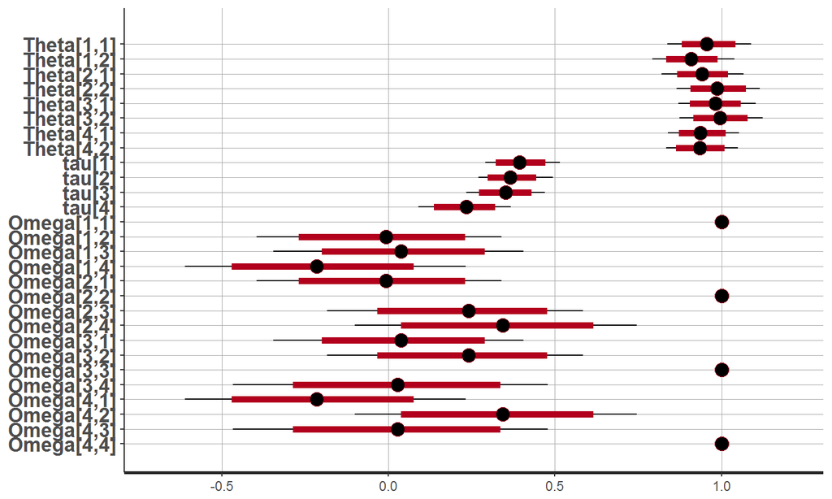

```r
plot(test.stan, pars=c("Theta", "tau", "Omega"))
```

## Visualize parameters (2)

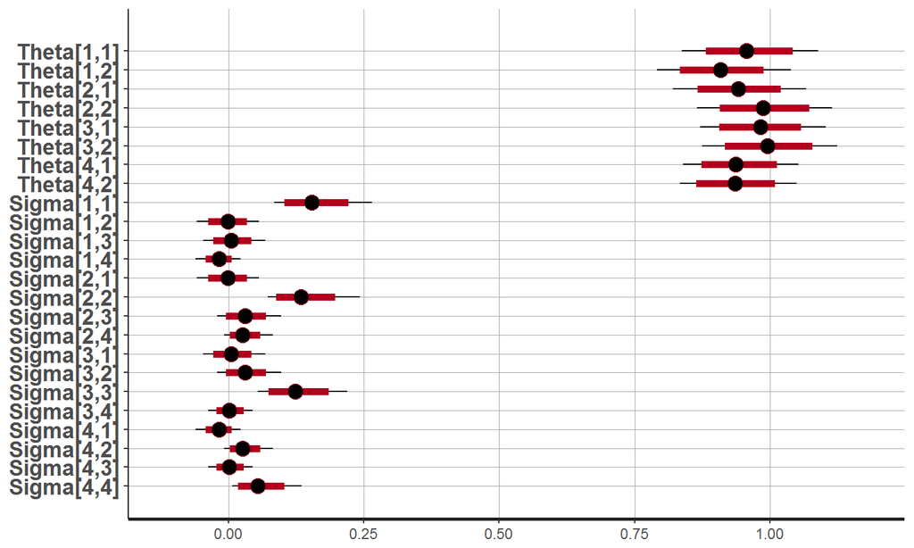

```r
plot(test.stan, pars=c("Theta", "Sigma"))
```

## Tidy up and read in the chocolate data

```r
rm(list=ls()) # tidy up
choc.df <- read.csv("cbc_chocolate.csv")
```

## Coding the chocolate data

We've done this twice now, so we ought to package it up as a function (but we haven't).

```r
choc.contrasts <- list(Brand = "contr.sum", Type = "contr.sum")
choc.coded <- model.matrix(~ Brand + Type, data = choc.df,
                           contrasts = choc.contrasts)
choc.coded <- choc.coded[,2:ncol(choc.coded)] # remove intercept
# Fix the bad labels from contr.sum
choc.names <- c("BrandDove", "BrandGhirardelli", "BrandGodiva",
                "BrandHersheys", "TypeDark", "TypeDarkNuts",
                "TypeMilk", "TypeMilkNuts")
colnames(choc.coded) <- choc.names
choc.df <- cbind(choc.df, choc.coded)
```

## Coded chocolate data

```r
head(choc.df)
```

```
##   X  Ind Trial Alt    Brand        Type Price Chosen BrandDove
## 1 1 2401     1   1     Dove        Milk   0.6      1         1
## 2 2 2401     1   2   Godiva        Dark   0.7      0         0
## 3 3 2401     1   3     Dove       White   3.6      0         1
## 4 4 2401     2   1   Godiva Milk w Nuts   2.7      0         0
## 5 5 2401     2   2   Godiva        Dark   3.9      1         0
## 6 6 2401     2   3 Hersheys Milk w Nuts   0.7      0         0
##   BrandGhirardelli BrandGodiva BrandHersheys TypeDark TypeDarkNuts
## 1                0           0             0        0            0
## 2                0           1             0        1            0
## 3                0           0             0       -1           -1
## 4                0           1             0        0            0
## 5                0           1             0        1            0
## 6                0           0             1        0            0
##   TypeMilk TypeMilkNuts
## 1        1            0
## 2        0            0
## 3       -1           -1
## 4        0            1
## 5        0            0
## 6        0            1
```

## Munge the data into Stan list format

```r
R <- length(unique(choc.df$Ind))
S <- length(unique(choc.df$Trial))
C <- max(choc.df$Alt)
K <- 9
Y <- array(dim=c(R, S))
X <- array(rnorm(R*S*C*K), dim=c(R, S, C, K))
Z <- array(1, dim=c(1, R)) # intercept only
for (r in 1:R) { # respondents
  for (s in 1:S){ # choice scenarios
    scenario <- choc.df[choc.df$Ind==unique(choc.df$Ind)[r] &
                        choc.df$Trial==unique(choc.df$Trial)[s], ]
    X[r,s,,] <- data.matrix(scenario[,c(7, 9:16)])
    Y[r,s] <- scenario$Alt[as.logical(scenario$Chosen)]
  }
}
choc.standata <- list(C=C, K=K, R=R, S=S, G=1, Y=Y, X=X, Z=Z)
```

## Check the chocolate data

```r
str(choc.standata)
```

```
## List of 8
##  $ C: int 3
##  $ K: num 9
##  $ R: int 14
##  $ S: int 25
##  $ G: num 1
##  $ Y: int [1:14, 1:25] 1 2 2 2 3 1 2 2 2 3 ...
##  $ X: num [1:14, 1:25, 1:3, 1:9] 0.6 2.2 1.4 3.9 3 3.8 0.6 1.4 2.2 1.8 ...
##  $ Z: num [1, 1:14] 1 1 1 1 1 1 1 1 1 1 ...
```

## Tidy up

```r
rm(Y, X, Z, R, S, r, s, C, K, choc.contrasts, scenario, choc.coded)
```

## Run the hmnl model with the chocolate data

## Bayesian inference

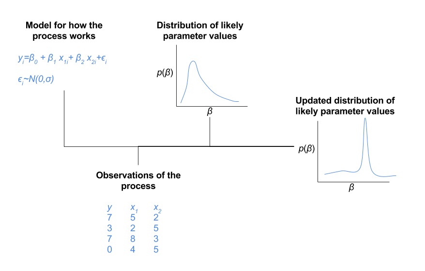

## Call the `stan()` function

```r
choc.stan <- stan(file="hmnl.stan", data=choc.standata)
```

## Assess convergence with tracelots (1)

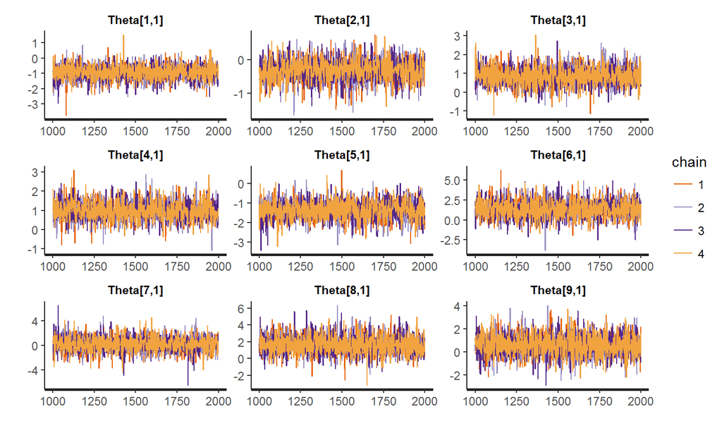

```r
plot(choc.stan, plotfun="trace", pars=("Theta"))
```

## Assess convergence with tracelots (1)

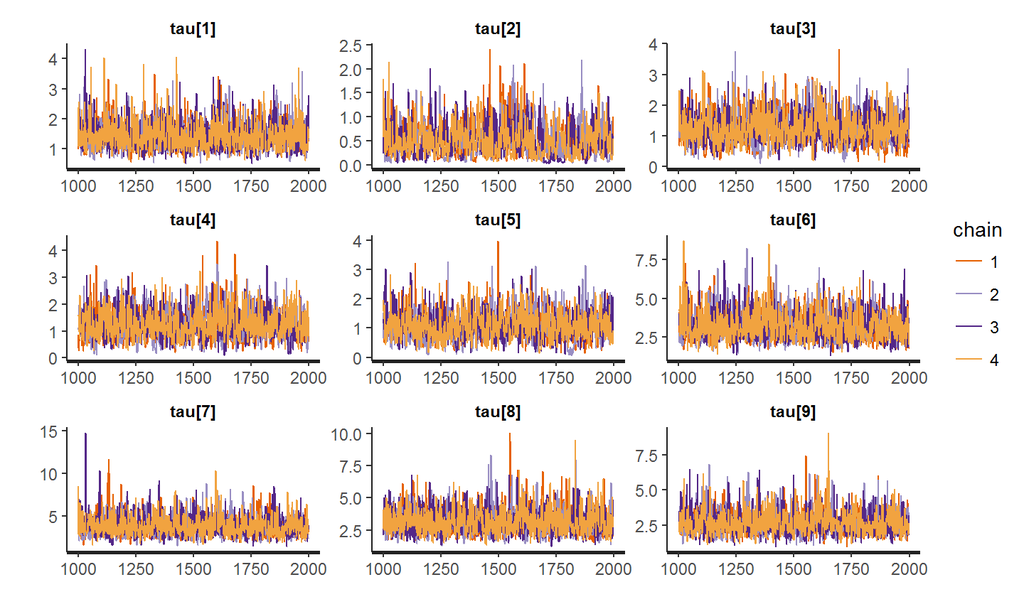

```r
plot(choc.stan, plotfun="trace", pars=c("tau"))
```

## Assess convergence with tracelots (1)

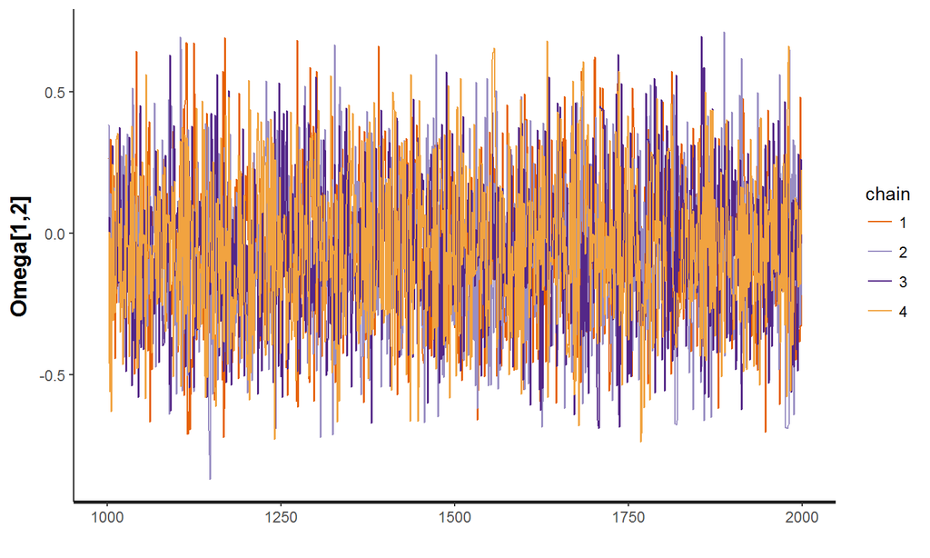

```r
plot(choc.stan, plotfun="trace", pars=c("Omega[1,2]"))
```

## Assess convergence with tracelots (1)

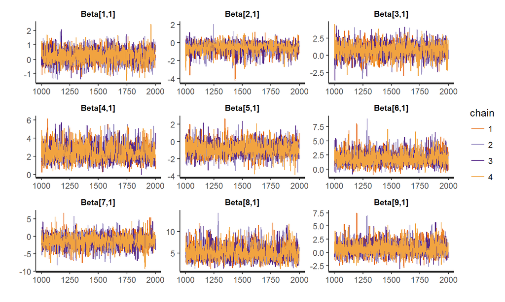

```r
plot(choc.stan, plotfun="trace", pars=paste("Beta[", 1:9, ",1]", sep="")) # resp 1
```

## Assess convergence with `Rhat` and `n_eff`

```r
summary(choc.stan)$summary[,c("Rhat", "n_eff")]
```

```
##                 Rhat     n_eff
## Beta[1,1]  0.9997071 4000.0000
## Beta[1,2]  1.0017911 4000.0000
## Beta[1,3]  1.0009621 1421.9471
## Beta[1,4]  1.0004392 4000.0000
## Beta[1,5]  0.9995330 4000.0000
## Beta[1,6]  0.9999020 4000.0000
## Beta[1,7]  1.0006088 4000.0000
## Beta[1,8]  1.0003296 2517.3810
## Beta[1,9]  1.0001914 2009.4926
## Beta[1,10] 0.9992727 4000.0000
## Beta[1,11] 0.9996400 4000.0000
## Beta[1,12] 1.0000986 4000.0000
## Beta[1,13] 0.9995063 4000.0000
## Beta[1,14] 1.0025173 1782.7831
## Beta[2,1]  1.0021741 1553.6648
## Beta[2,2]  1.0002684 2085.4639
## Beta[2,3]  1.0013789 2030.2115
## Beta[2,4]  1.0038554  975.9799
## Beta[2,5]  1.0006113 1624.3892
## Beta[2,6]  1.0014565 2348.7326
## Beta[2,7]  1.0006048 2084.1197
## Beta[2,8]  0.9996767 2715.4338
## Beta[2,9]  1.0024258  722.9200
## Beta[2,10] 1.0018361 1937.4611
## Beta[2,11] 1.0005320 2313.2303
## Beta[2,12] 1.0041430 1220.9866
## Beta[2,13] 1.0004681 2466.1466
## Beta[2,14] 0.9999157 3095.7829
## Beta[3,1]  1.0005838 2135.0053
## Beta[3,2]  0.9998939 2633.3025
## Beta[3,3]  1.0018833 2893.2396
## Beta[3,4]  1.0027297 1043.7732
## Beta[3,5]  1.0003045 4000.0000
## Beta[3,6]  1.0019515 4000.0000
## Beta[3,7]  1.0016896 1990.8186
## Beta[3,8]  1.0023727 2055.5701
## Beta[3,9]  1.0014179 1770.2464
## Beta[3,10] 1.0016108 1597.5935
## Beta[3,11] 1.0009055 4000.0000
```

[output cut: 253 more lines]

```
## Sigma[8,5] 1.0014179 2083.2480
## Sigma[8,6] 1.0007908 3001.4811
## Sigma[8,7] 1.0020650 1948.8037
## Sigma[8,8] 1.0011743 1299.7469
## Sigma[8,9] 1.0011831 2396.1701
## Sigma[9,1] 0.9998040 2854.6951
## Sigma[9,2] 1.0018692 1557.9496
## Sigma[9,3] 1.0001917 1989.9487
## Sigma[9,4] 0.9994933 2941.0178
## Sigma[9,5] 1.0011260 2395.8703
## Sigma[9,6] 1.0026454 2148.9206
## Sigma[9,7] 1.0014865 1423.9169
## Sigma[9,8] 1.0011831 2396.1701
## Sigma[9,9] 1.0012970 1214.6551
## lp__       1.0128243  288.2359
```

## Function for convergence checking

In a hierarchical model with many parameters, manually checking for convergence is pretty tedious. So, we can write a function to automate that for us.

```r
check_fit <- function(fit) {
  summ <- summary(fit)$summary
  range_rhat <- range(summ[ , 'Rhat'])
  rhat_ok <- 0.99 <= range_rhat[1] && range_rhat[2] <= 1.1
  range_neff <- range(summ[ , 'n_eff'])
  neff_ok <- range_neff[1] >= 400
  sp <- rstan::get_sampler_params(fit, inc_warmup=FALSE)
  max_divergent <- max(sapply(sp, function(p){ sum(p[ , 'divergent__']) }))
  no_divergent <- max_divergent == 0

  list(ok = rhat_ok && neff_ok && no_divergent,
       range_rhat = range_rhat,
       range_neff = range_neff,
       max_divergent = max_divergent)
}
```

## Checking convergence

Our model isn't converging well :(  
This is likely due to data limitations; we have just 14 respondents and 9 attributes.

```r
check_fit(choc.stan)
```

```
## $ok
## [1] FALSE
##
## $range_rhat
## [1] NaN NaN
##
## $range_neff
## [1]  288.2359 4000.0000
##
## $max_divergent
## [1] 17
```

## Options for addressing convergence problems

- Consider whether there are any pathologies in the model specification
  - unlikely in this case
- Run the algorithm for longer
- Get more data
- Tighten up the priors

We are going to move on to use these posterior draws although we should probably not.

## Summarizing the posterior distribution of the parameters

## Attributes

Remember, the attributes are:

```r
c("Price", choc.names)
```

```
## [1] "Price"            "BrandDove"        "BrandGhirardelli"
## [4] "BrandGodiva"      "BrandHersheys"    "TypeDark"
## [7] "TypeDarkNuts"     "TypeMilk"         "TypeMilkNuts"
```

## Visualize the parameter estimates (1)

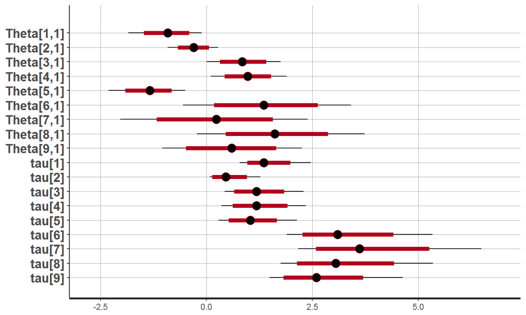

```r
plot(choc.stan, pars=c("Theta", "tau"))
```

It is a shame that you can't give descriptive names to the attributes in Stan.

## Visualize the parameter estimates (2)

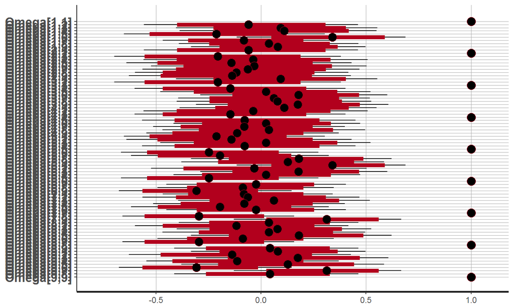

```r
plot(choc.stan, pars=c("Omega"))
```

## Visualize the parameter estimates (3)

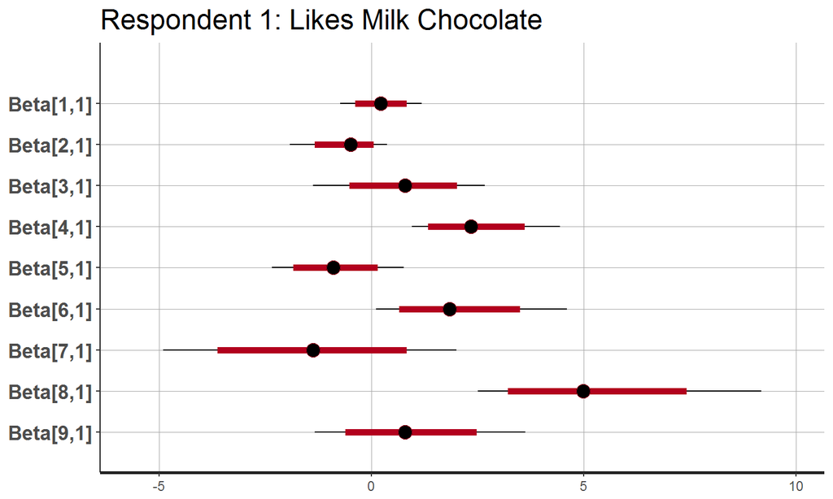

```r
plot(choc.stan, pars=paste("Beta[", 1:9, ",1]", sep="")) +
  ggtitle("Respondent 1: Likes Milk Chocolate")
```

## Visualize the parameter estimates (4)

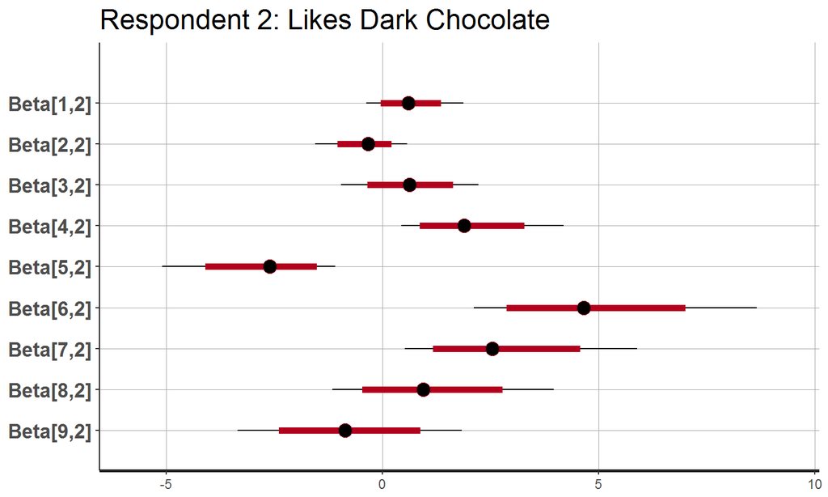

```r
plot(choc.stan, pars=paste("Beta[", 1:9, ",2]", sep="")) +
  ggtitle("Respondent 2: Likes Dark Chocolate")
```

## More posterior checking in ShinyStan

```r
launch_shinystan(choc.stan)
```

## Simulating shares

## Simulating shares from the hmnl

One way to simulate shares from a hierarchical model is to use the draws of the respondent-level parameters (`beta`).

```r
shares.hmnl.post <- function(beta.draws, X) # X is attribute matrix
{
  R <- dim(beta.draws)[3]  # respondents
  D <- dim(beta.draws)[1]  # draws
  shares <- array(NA, dim=c(nrow(X), R, D))
  for (d in 1:D) {
    for (r in 1:R) {
      beta <- beta.draws[d,,r]
      V <- exp(X %*% beta)
      shares[,r,d] <- V/sum(V)
    }
  }
  shares
}
```

## New choice set

```r
choc.standata$X[1,1,,]
```

```
##      [,1] [,2] [,3] [,4] [,5] [,6] [,7] [,8] [,9]
## [1,]  0.6    1    0    0    0    0    0    1    0
## [2,]  0.7    0    0    1    0    1    0    0    0
## [3,]  3.6    1    0    0    0   -1   -1   -1   -1
```

```r
rbind(c("Price", choc.names), choc.standata$X[1,1,,])
```

```
##      [,1]    [,2]        [,3]               [,4]          [,5]
## [1,] "Price" "BrandDove" "BrandGhirardelli" "BrandGodiva" "BrandHersheys"
## [2,] "0.6"   "1"         "0"                "0"           "0"
## [3,] "0.7"   "0"         "0"                "1"           "0"
## [4,] "3.6"   "1"         "0"                "0"           "0"
##      [,6]       [,7]           [,8]       [,9]
## [1,] "TypeDark" "TypeDarkNuts" "TypeMilk" "TypeMilkNuts"
## [2,] "0"        "0"            "1"        "0"
## [3,] "1"        "0"            "0"        "0"
## [4,] "-1"       "-1"           "-1"       "-1"
```

## Simulated shares for each respondent

```r
shares <- shares.hmnl.post(extract(choc.stan, pars=c("Beta"))$Beta,
                          choc.standata$X[1,1,,])
str(shares)
```

```
##  num [1:3, 1:14, 1:4000] 9.74e-02 9.03e-01 1.09e-11 9.51e-03 9.90e-01 ...
```

## Summary of simulated shares

Our uncertainty (with only 14 respondents) is reflected in our share predictions

```r
apply(shares, 1, quantile, probs=c(0.5, 0.025, 0.975))
```

```
##               [,1]         [,2]         [,3]
## 50%   3.367202e-01 0.6572168658 5.770520e-05
## 2.5%  3.238036e-05 0.0005594159 1.020469e-11
## 97.5% 9.990943e-01 0.9998979505 7.294112e-02
```

## Share predictions for indivdiuals

```r
apply(shares, 1:2, quantile, probs=c(0.5, 0.025, 0.975))
```

```
## , , 1
##
##             [,1]       [,2]         [,3]
## 50%   0.54680577 0.45225251 1.698918e-05
## 2.5%  0.08162233 0.05309691 1.729492e-11
## 97.5% 0.94592919 0.91811230 9.000318e-03
##
## , , 2
##
##               [,1]      [,2]         [,3]
## 50%   2.454452e-03 0.9970964 4.409958e-06
## 2.5%  1.541075e-05 0.8972938 1.884778e-12
## 97.5% 9.058789e-02 0.9999810 1.507253e-02
##
## , , 3
##
##            [,1]         [,2]         [,3]
## 50%   0.9489084 0.0509947909 3.279996e-06
## 2.5%  0.5202464 0.0007028624 2.565718e-10
## 97.5% 0.9992970 0.4797240828 9.633767e-04
##
## , , 4
##
##             [,1]        [,2]         [,3]
## 50%   0.69006987 0.308498375 4.074428e-06
## 2.5%  0.05698367 0.008389946 2.225102e-12
## 97.5% 0.99142028 0.941931215 8.558655e-03
##
## , , 5
##
##              [,1]      [,2]         [,3]
## 50%   0.077607209 0.9211337 1.111198e-04
## 2.5%  0.001928762 0.2982351 3.082569e-07
## 97.5% 0.699270490 0.9980561 7.074281e-03
##
## , , 6
##
##             [,1]         [,2]         [,3]
## 50%   0.78488841 0.2091954573 6.052141e-04
## 2.5%  0.04968968 0.0006808003 6.344486e-07
```

[output cut: 42 more lines]

```
## 97.5% 2.956102e-02 0.9999866 1.426109e-01
##
## , , 13
##
##              [,1]      [,2]         [,3]
## 50%   0.068247102 0.9302802 3.670161e-05
## 2.5%  0.002269619 0.3412264 7.909814e-11
## 97.5% 0.657149025 0.9976578 1.572743e-02
##
## , , 14
##
##            [,1]      [,2]         [,3]
## 50%   0.2656475 0.7340703 4.081641e-06
## 2.5%  0.0247284 0.1848133 4.106086e-09
## 97.5% 0.8151838 0.9752713 4.893263e-04
```

## Summary of Module 3

## In this module we have:

- Built a hierarchical multnomial model in Stan.
  - multivariate normal distribution
  - correlation and covariance matrices
  - LKJ prior
  - transformed parameters
- Tested it with synthetic data
- Estimated it using the chocolate cbc data
- Learned how to automate the process of checking convergence
- Simulated shares from a hierarchical model

## Next in Module 4

The next module will illustrate the real power of Stan, which is to flexibly create new models.